# Natural Gas Spot Price VaR

# Introduction

This project takes inspiration from the 2021–2023 global energy crisis. Triggered by post-pandemic economic rebound and exacerbated by the Russian invasion of Ukraine, this crisis led to record-high natural gas and electricity prices. Our objective is to calculate a robust Value at Risk (VaR) for risk assessment in gas market short positions. This is crucial in ensuring informed decision-making within the volatile energy landscape.

```r
library(quantmod)
library(zoo)
library(MASS)
library(tidyverse)
library(ggplot2)
library(lubridate)
```

### Scrapping daily gas price from FRED

```r
gas <- getSymbols("DHHNGSP",src="FRED",auto.assign=FALSE)
gas <- na.omit(gas)
gas <- gas["1979-12-31/2022-12-31"]
gas <- gas # we want daily returns
```

```r
tail(gas)
```

```
           DHHNGSP
2022-12-22    7.10
2022-12-23    7.15
2022-12-27    4.88
2022-12-28    4.06
2022-12-29    3.78
2022-12-30    3.52
```

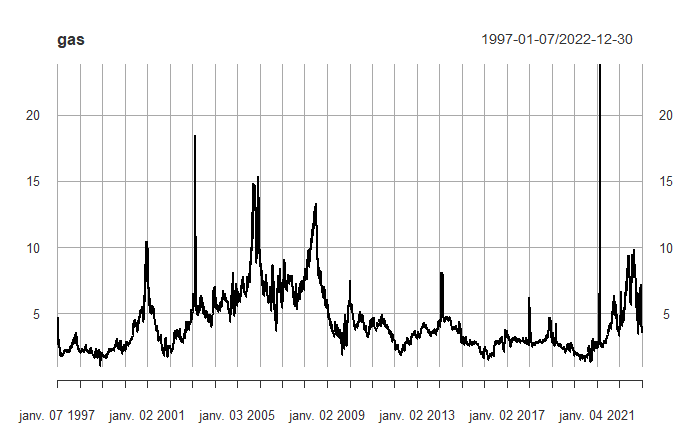

```r
plot(gas,type="l")
```

```r
sum(is.na(gas))
```

```
[1] 0
```

```r
length(gas)
```

```
[1] 6535
```

### Daily log return

```r
logret <- as.numeric(diff(log(gas))[-1])
head(logret, 3)
```

```
[1] -0.005249356 -0.051293294  0.082383881
```

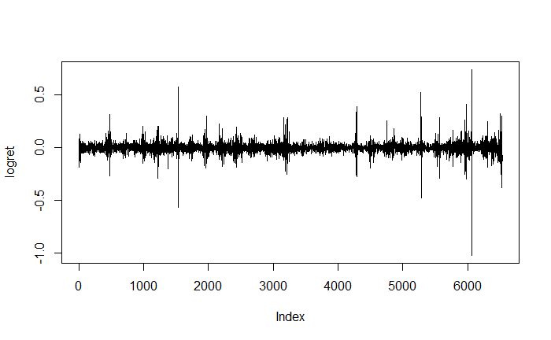

```r
plot(logret,type="l")
```

### Normality of the daily returns

```r
hist(logret,breaks = 100,freq=F,ylim=c(0,18))
xfit <- seq(min(logret),max(logret),length=length(logret))
yfit <- dnorm(xfit,mean(logret),sd(logret))
lines(xfit,yfit,col="red",lwd=2)
```

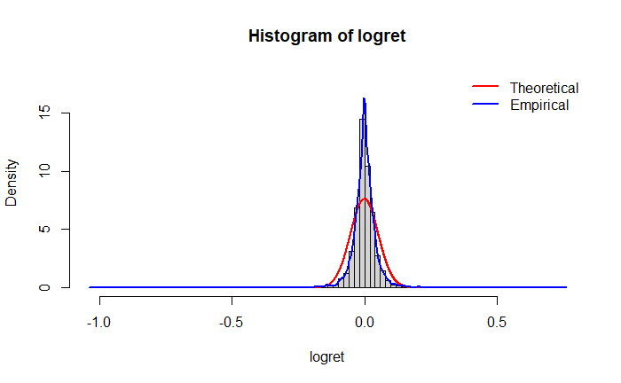

```r
lines(density(logret),col="blue",lwd=2)
legend("topright", legend = c("Theoretical","Empirical"),
       col = c("red", "blue"), lty = 1, lwd=2, bty = "n")
```

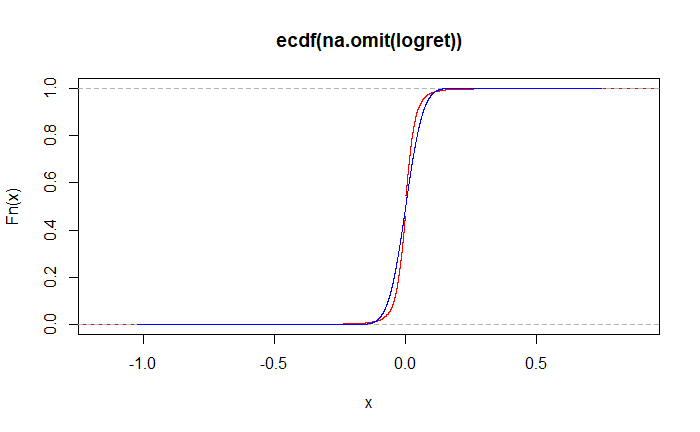

```r
plot(ecdf(na.omit(logret)),col="red")
lines(x=xfit,y=cumsum(yfit)/max(cumsum(yfit)),col="blue")
```

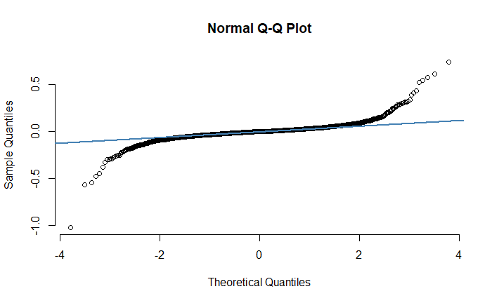

```r
qqnorm(logret, pch = 1, frame = FALSE)
qqline(logret, col = "steelblue", lwd = 2)
```

Skewness and kurtosis of daily log returns

```r
library(moments)
```

```r
skewness(logret)
```

```
[1] -0.1701927
```

```r
kurtosis(logret)
```

```
[1] 52.6747
```

The kurtosis of daily return is very high.

```r
jarque.test(as.vector(logret))
```

```
    Jarque-Bera Normality Test

data:  as.vector(logret)
JB = 671829, p-value < 2.2e-16
alternative hypothesis: greater
```

Si since p-value < 0.05, then the daily returns aren’t normal.

Daily return’s distribution is skewed to the left, so we need to model it using another distribution. Fitting scaled Student distribution to log return using Maximum-likelihood.

```r
suppressWarnings(t.fit <- fitdistr(logret, "t"))
```

```r
round(t.fit$estimate,6)
```

```
        m         s        df
-0.000321  0.025200  2.443520
```

```r
library(metRology)
```

```r
hist(logret,breaks = 100,freq=F,ylim=c(0,18))
xfit <- seq(min(logret),max(logret),length=length(logret))
yfit <- dt.scaled(xfit,mean=t.fit$estimate[1],sd=t.fit$estimate[2],df=t.fit$estimate[3])
lines(xfit,yfit,col="red",lwd=2)
```

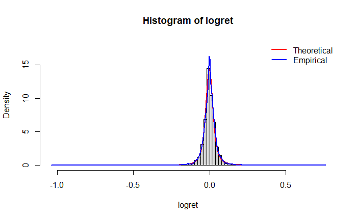

```r
lines(density(logret),col="blue",lwd=2)
legend("topright", legend = c("Theoretical","Empirical"),
       col = c("red", "blue"), lty = 1, lwd=2, bty = "n")
```

QQ-Plot

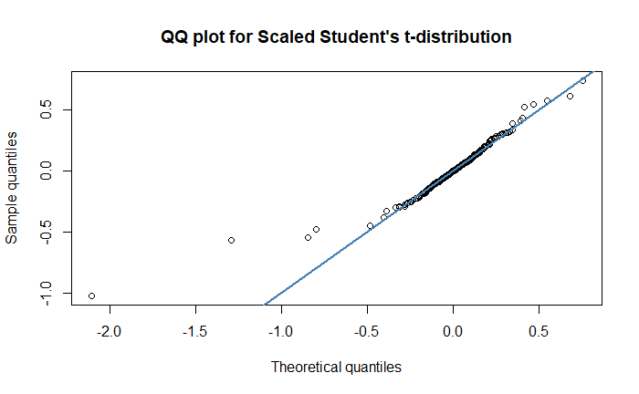

```r
returns.sample <- rt.scaled(length(logret),mean=t.fit$estimate[1],sd=t.fit$estimate[2],df=t.fit$estimate[3])
ordered.returns.sample <- returns.sample[order(returns.sample)]
vector.logret <- as.vector(logret)
ordred.logret <- vector.logret[order(vector.logret)]
plot(ordered.returns.sample,ordred.logret,main="QQ plot for Scaled Student's t-distribution",xlab="Theoretical quantiles", ylab="Sample quantiles")
abline(0,1,col="steelblue",lwd=2)
```

```r
plot(ecdf(returns.sample),col="red")
lines(ecdf(logret),col="blue")
```

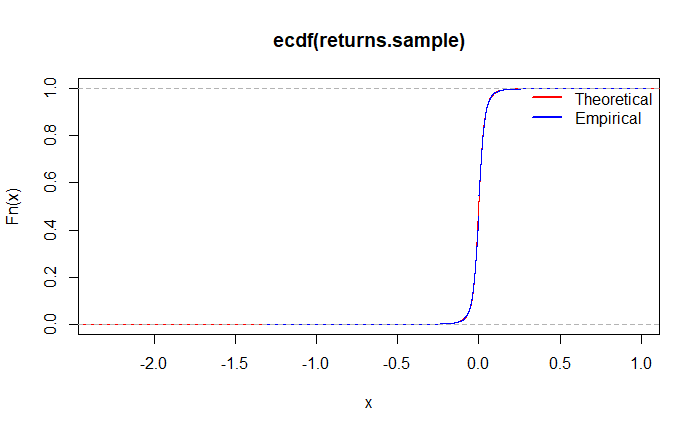

```r
legend("topright", legend = c("Theoretical","Empirical"),
       col = c("red", "blue"), lty = 1, lwd=2, bty = "n")
```

```r
ks.test(returns.sample,logret)
```

```
    Asymptotic two-sample Kolmogorov-Smirnov test

data:  returns.sample and logret
D = 0.064126, p-value = 4.286e-12
alternative hypothesis: two-sided
```

From the the Q-Q plot we Formulate the hypothesis that the dt-distribution is a good candidate for return distribution, however the Kolmogorov-Smirnov test reject this hypothesis. Estimating VaR and ES using Scaled Student’s t-distribution
$$\text{Let } L \text{ be the loss of the gas prices and } n \text{ be
the length of } L$$
$$\text{VaR is defined as : } VaR_{\alpha} = inf( l \in \mathbb{R},
P(L>\alpha)≤ 1 − \alpha)$$
$$\text{We estimate the expected shortfall using conditional expectation :
} ES_{\alpha} = \mathbb{E}(L | L ≥ VaRα).$$

```r
VaR.scaled.student <- function(alpha){
var <- qt.scaled(alpha,mean=t.fit$estimate[1],sd=t.fit$estimate[2],df=t.fit$estimate[3])
return(as.numeric(var))
}
VaR <- VaR.scaled.student(0.01)
return.sample <- rt.scaled(100000,mean=t.fit$estimate[1],sd=t.fit$estimate[2],df=t.fit$estimate[3])
ES <- mean(return.sample[return.sample<VaR])
```

```r
c(VaR,ES)
```

```
[1] -0.1384333 -0.2352469
```

## Extreme Value theory

The presence of serious changes in the gas price disrupts the assumption of homogeneous risks. We will apply some of the fundamentals of extreme value theory to determine determine a threshold at which a loss can be considered atypical.

```r
library(evir)
```

```r
X <- -logret[logret<0]
n <- length(X)
log.X <- numeric(n)
Standard.exp.quantiles <- numeric(n)
orderd.X <- sort(as.vector(X))
for(j in 1:n){
  Standard.exp.quantiles[j] <- log((n+1)/j)
  log.X[j] <- log(orderd.X[n-j+1])
}
```

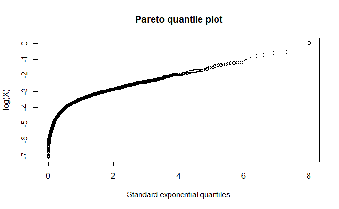

```r
plot(Standard.exp.quantiles,log.X,xlab="Standard exponential quantiles",ylab="log(X)",main="Pareto quantile plot")
```

### Generalized Quantile Plot

$$\text{The Generalized Quantile Plot corresponds to }\left(\ln
\left(\frac{n+1}{j+1}\right), \ln \left(U H_{j, n}\right)\right) \\
\text{Where } U H_{j, n}=X_{n-j, n}\left(\frac{1}{j} \sum_{i=1}^{j} \ln
\left(X_{n-i+1, n}\right)-\ln \left(X_{n-j, n}\right)\right)$$

```r
UH <- numeric(n)
Standard.exp.quantiles <- numeric(n)
for(j in 1:(n-1)){
  Standard.exp.quantiles[j] <- log((n+1)/(j+1))
  UH[j] <- 0
  for(i in 1:j){
    UH[j] <- UH[j]  + log(orderd.X[n-i+1]/orderd.X[n-j])
  }
  UH[j] <- UH[j]*orderd.X[n-j]/j
}
```

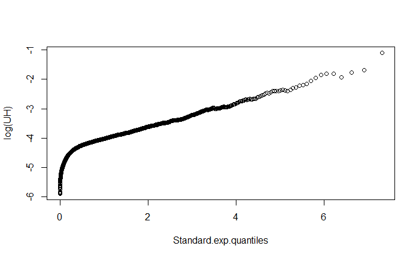

```r
plot(Standard.exp.quantiles,log(UH))
```

The extreme points form a straight line with a positive slope, which means we are in the Fréchet domain. ### Threshold Stability Plot

```r
library(POT)
```

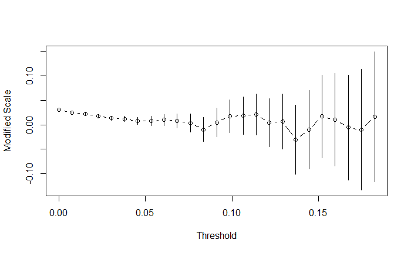

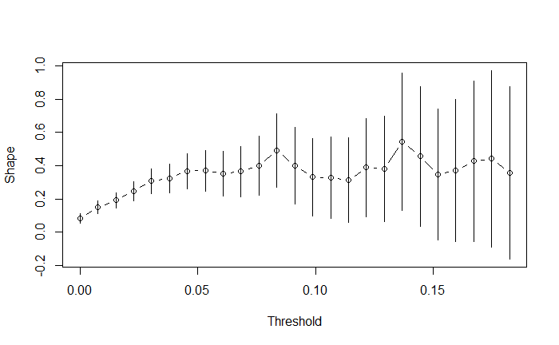

```r
tcplot(X,u.range=c(0,quantile(X,probs=0.99)))
```

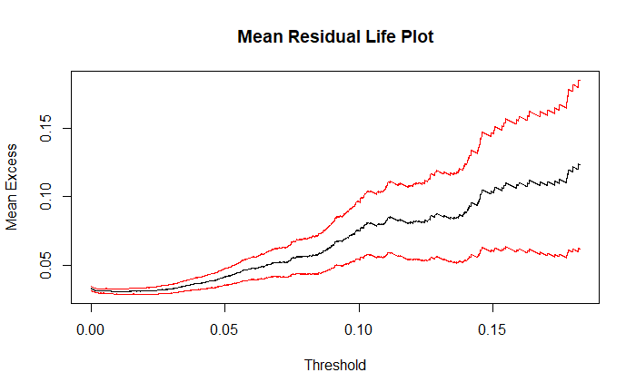

```r
mrlplot(X,u.range=c(0,quantile(X,probs=0.99)),col=c("red","black","red"))
```

According to the analysis of the two graphs, parameter stabilization is significant above 0.12. ### Mean Excess Plot
$$e(u) = E(X-u|X>u)$$
According to the analysis of the Mean Excess Plot, above 0.12 the mean excess estimate is linear with positive slope which indicate that the log returns follow a Generalized Pareto distribution with a positive tail parameter.

```r
THreshold <- 0.12
```

## Peak Over Threshold

```r
extreme.logret <- X[X > THreshold]
```

```r
summary(extreme.logret)
```

```
   Min. 1st Qu.  Median    Mean 3rd Qu.    Max.
 0.1201  0.1388  0.1565  0.2008  0.2092  1.0251
```

```r
length(extreme.logret)
```

```
[1] 86
```

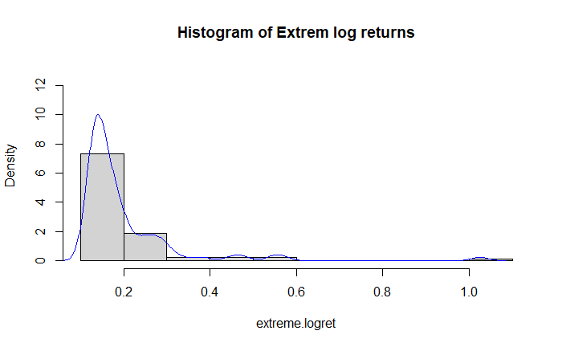

```r
hist(extreme.logret,main="Histogram of Extrem log returns",freq=F,ylim=c(0,13))
lines(density(extreme.logret),col="blue")
```

### Generalized pareto distribution

$$GPD(\mu,\sigma,\xi) : f_{(\mu,\sigma,\xi)}(x) =
\frac{1}{\sigma}(1+\xi(\frac{x-\mu}{\sigma}))^{-(1+\frac{1}{\xi})}$$

```r
library(eva)
```

```r
mle_fit <- gpdFit(X, threshold = THreshold, method = "mle")
```

```r
mle_fit$par.ests
```

```
Scale (Intercept) Shape (Intercept)
       0.04968228        0.39812722
```

```r
mle_fit
```

```
Summary of fit:
```

|  | Estimate | Std. Error | z value | Pr(>\|z\|) |  |
| --- | --- | --- | --- | --- | --- |
| Scale (Intercept) | 0.04968228 | 0.00895861 | 5.545758 | 2.926841e-08 | *** |
| Shape (Intercept) | 0.39812722 | 0.15076394 | 2.640732 | 8.272701e-03 | ** |

```
---
Signif. codes:  0 '***' 0.001 '*' 0.01 '*' 0.05 '.' 0.1 ' ' 1
```

The shape is positive then we are modeling a pareto distribution
$$GPD(\mu,\sigma,\xi) : f_{(\mu,\sigma,\xi)}(x) =
\frac{1}{\sigma}(1+\xi(\frac{x-\mu}{\sigma}))^{-(1+\frac{1}{\xi})}$$

```r
Pareto.pdf <- function(x,location,scale,shape){
  a <- 1+(1/shape)
  b <- (x-location)/scale
  return((1+shape*b)^(-a)/scale)
}
```

```r
# Set the estimated parameters
location <- THreshold
scale <- as.numeric(mle_fit$par.ests[1])
shape <- as.numeric(mle_fit$par.ests[2])
hist(extreme.logret,freq = F,breaks=50)
x <- seq(from = 0, to = max(extreme.logret), length.out = 100)
lines(density(extreme.logret),col='blue',lwd=2)
```

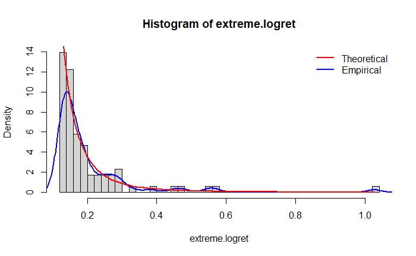

```r
lines(x,y=Pareto.pdf(x,location,scale,shape),type="l",col="red",lwd=2)
legend("topright", legend = c("Theoretical","Empirical"),
       col = c("red", "blue"), lty = 1, lwd=2, bty = "n")
```

QQ-Plot

```r
library(evmix)
```

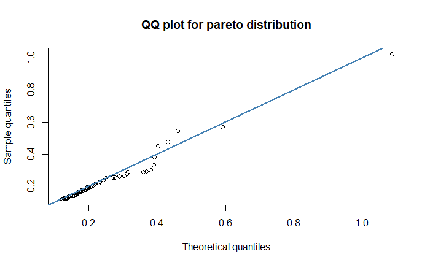

```r
returns.sample <- rgpd(n = length(extreme.logret), u = location, sigmau = scale, xi = shape, phiu = 1)
ordered.returns.sample <- sort(returns.sample)
vector.logret <- as.vector(extreme.logret)
ordred.logret <- sort(vector.logret)
plot(ordered.returns.sample,ordred.logret,main="QQ plot for pareto distribution",xlab="Theoretical quantiles", ylab="Sample quantiles")
abline(0,1,col="steelblue",lwd=2)
```

```r
plot(ecdf(vector.logret),col="red")
lines(ecdf(ordred.logret),col="blue")
```

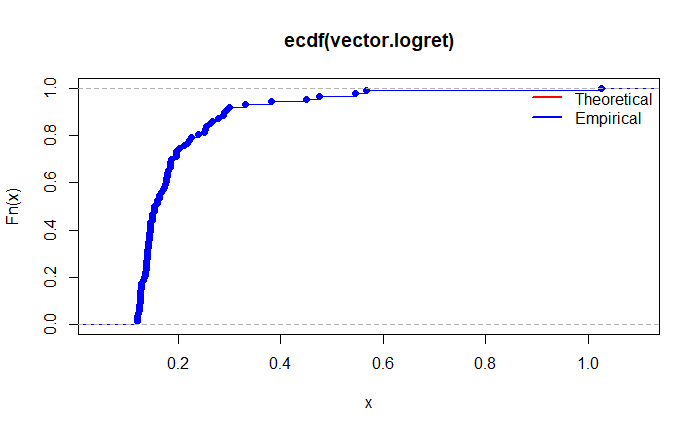

```r
legend("topright", legend = c("Theoretical","Empirical"),
       col = c("red", "blue"), lty = 1, lwd=2, bty = "n")
```

## Calculate VaR

$$\text{Let denote the cumulative distribution function of }
{\displaystyle X\sim GPD(\mu ,\sigma ,\xi )} \text{ by } G(x): \\
{\displaystyle G_{(\mu ,\sigma ,\xi
)}(x)={\begin{cases}1-\left(1+{\frac {\xi (x-\mu )}{\sigma
}}\right)^{-1/\xi }&{\text{for }}\xi \neq 0,\\1-\exp \left(-{\frac
{x-\mu }{\sigma }}\right)&{\text{for }}\xi =0,\end{cases}}} \\
{\displaystyle G_{(\mu ,\sigma ,\xi )}^{-1}(x)={\begin{cases}
\mu+\frac{\sigma}{\xi}((\frac{1}{1-x})^{\xi}-1)
&{\text{for }}\xi \neq 0,\\
\mu+\sigma\ln \left({\frac {1}{1-x}}\right)&{\text{for }}\xi
=0,\end{cases}}}$$

```r
Pareto.cdf <- function(x,location,scale,shape){
  a <- shape*(x-location)/scale
  b <- -1/shape
  return(1-(1+a)^b)
}
```

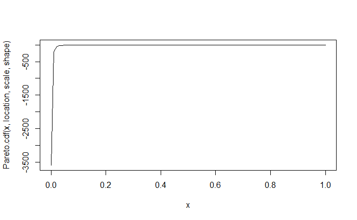

```r
x <- seq(from = 0, to = as.integer(max(extreme.logret)), length.out = 100)
plot(x,Pareto.cdf(x,location,scale,shape),type="l")
```

```r
Inverse.cdf.Pareto <- function(x,location,scale,shape){
  a <- scale/shape
  b <- (1/(1-x))^shape
  return(location+a*(b-1))
}
```

```r
VaR <- function(alpha,location,scale,shape,n,N){
  x <- 1-(n/N)*alpha
  return(Inverse.cdf.Pareto(x,location,scale,shape))
}
```

```r
alpha <- 0.01
N <- length(extreme.logret)
n <- length(logret)
Pareto.VaR <- as.numeric(-VaR(alpha,location,scale,shape,n,N))
print(Pareto.VaR)
```

```
[1] -0.1344244
```

```r
library(xts)
```

```r
new.log.ret <- na.omit(diff(log(gas))[-1])
```

```r
new.log.ret <- xts(new.log.ret$DHHNGSP, order.by = as.Date(index(new.log.ret)))
```

```r
weekly.maxima <- -apply.weekly(new.log.ret, FUN = min)$DHHNGSP
```

```r
length(weekly.maxima)
```

```
[1] 1355
```

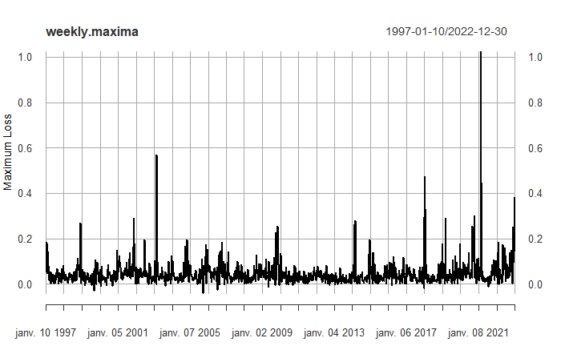

```r
plot(weekly.maxima,type="l",xlab = "Week",ylab = "Maximum Loss")
```

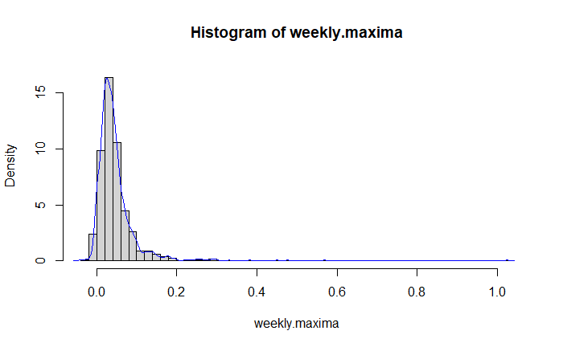

```r
hist(weekly.maxima,freq = F,ylim = c(0,17),breaks=50)
lines(density(weekly.maxima),main="Histogram of Weekly Maximas",col="blue")
```

### Generalized extreme value distribution

$$GEV(\mu,\sigma,\xi) : f_{(\mu,\sigma,\xi)}(x) =
\frac{1}{\sigma}t(x)^{\xi+1}e^{-t(x)} \\
\text{Where : } t(x) = \begin{cases}
(1+\xi(\frac{x-\mu}{\sigma}))^{-\frac{1}{\xi}} & \text{if } \xi \neq
0 \\
e^{-(\frac{x-\mu}{\sigma})} & \text{if } \xi = 0
\end{cases}$$

```r
library(extRemes)
```

```r
fevd(weekly.maxima)
```

```
fevd(x = weekly.maxima)

[1] "Estimation Method used: MLE"


 Negative Log-Likelihood Value:  -2749.904


 Estimated parameters:
  location      scale      shape
0.02676965 0.02531254 0.13040335

 Standard Error Estimates:
    location        scale        shape
0.0007401588 0.0005464345 0.0133238584

 Estimated parameter covariance matrix.
              location        scale         shape
location  5.478350e-07 1.808790e-07 -1.554289e-06
scale     1.808790e-07 2.985906e-07  1.345930e-06
shape    -1.554289e-06 1.345930e-06  1.775252e-04

 AIC = -5493.808

 BIC = -5478.173
```

```r
Weibull.pdf <- function(x,location,scale,shape){
  t.x <- (1+(shape*(x-location))/(scale))^(-1/shape)
  return(((1/scale)*t.x^(1+shape))*exp(-t.x))
}
```

```r
# Set the estimated parameters
location <- 0.02676965
scale <- 0.02531254
shape <- 0.13040335
hist(weekly.maxima,freq = FALSE,ylim = c(0,17),breaks=50)
x <- seq(from = 0,to = as.integer(max(weekly.maxima)), length.out = 100)
lines(density(weekly.maxima),col="red",lwd=2)
```

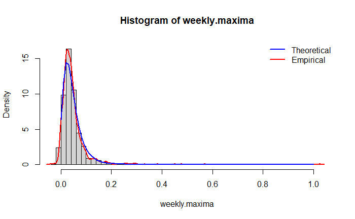

```r
lines(x,y=Weibull.pdf(x,location,scale,shape),type="l",col="blue",lwd=2)
legend("topright", legend = c("Theoretical","Empirical"),
       col = c("blue", "red"), lty = 1, lwd=2, bty = "n")
```

$$\text{The VaR is given by : }
VaR(\alpha) = \begin{cases}
\mu-\frac{\sigma}{\xi}(1-(-m ln(\alpha)^{-{\xi}}) & \text{if } \xi
\neq 0 \\
\mu-\sigma ln(-m ln(\alpha)) & \text{if } \xi = 0
\end{cases}$$

```r
Weibull.VaR <- function(alpha,location,scale,shape,m){
  return(location-(scale/shape)*(1-(-m*log(alpha))^(-shape)))
}
```

```r
m <- length(weekly.maxima)
weibull.VaR <- Weibull.VaR(alpha,location,scale,shape,m)
weibull.VaR
```

```
[1] -0.1052327
```

```r
weibull.ES <- mean(logret[logret<weibull.VaR])
weibull.ES
```

```
[1] -0.1852137
```

## Comparing different methods for computing risk measures

```r
risk.measures <- data.frame(
  "Normal" = c(quantile(logret,alpha),mean(logret[logret<quantile(logret,alpha)])),
  "Scaled Student" = c(VaR.scaled.student(alpha),mean(logret[logret<VaR.scaled.student(alpha)])),
  "Pareto" = c(Pareto.VaR,mean(logret[logret<Pareto.VaR])),
  "Weibull" = c(weibull.VaR,weibull.ES)
)
```

```r
row.names(risk.measures ) <- c("VaR","ES")
```

```r
risk.measures
```

|  | Normal | Scaled.Student | Pareto | Weibull |
| --- | --- | --- | --- | --- |
| VaR | -0.1372596 | -0.1384333 | -0.1344244 | -0.1052327 |
| ES | -0.2230219 | -0.2243395 | -0.2192471 | -0.1852137 |

```r
library(tseries)
```

```r
adf.test(logret)
```

```
    Augmented Dickey-Fuller Test

data:  logret
Dickey-Fuller = -20.774, Lag order = 18, p-value = 0.01
alternative hypothesis: stationary
```

The p-value is 0.01 which means we have enough evidence to reject the null hypothesis “Log return are not stationary”. Autocorrelation

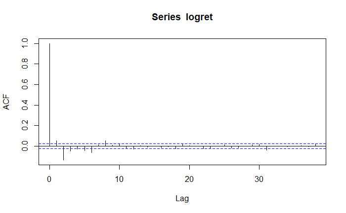

```r
acf(logret)
```

Serial correlation

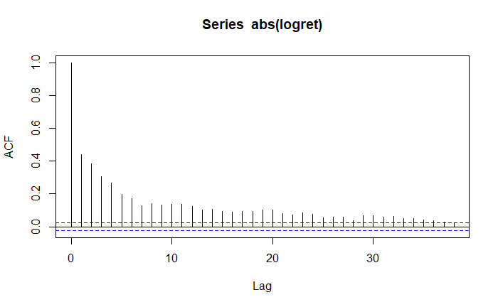

```r
acf(abs(logret))
```

The log returns exhibit serial correlation, then Garch model would be a good fit for the daily returns Volatility clustering

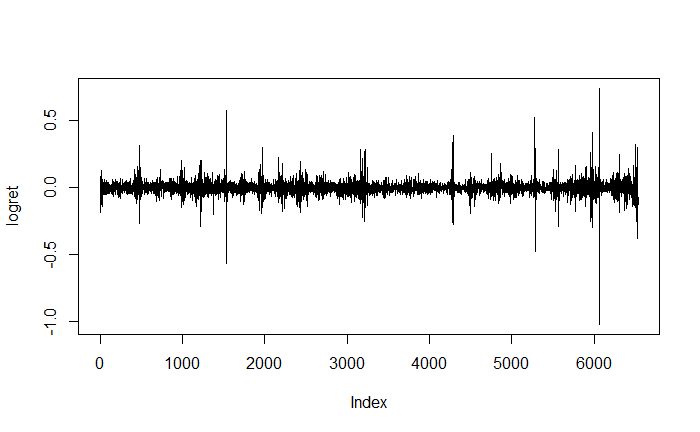

```r
plot(logret,type="l")
```

High volatility are clustered in time.

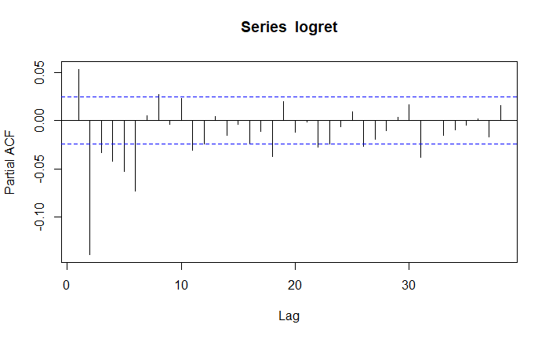

```r
pacf(logret)
```

GARCH(1,1) Model : using normal distribution of residuals
$$r_t = \mu + \epsilon_t = \mu + \sigma_t \eta_t \\
\sigma_t^2 = \omega + \alpha \epsilon_t^2 + \beta \sigma_{t-1}^2 \\
\text{Where } \eta_t \sim \mathbb{N(0,1)}$$

```r
library(rugarch)
uspec <- ugarchspec( variance.model = list(model = "sGARCH",garchOrder = c(1,1)),
 mean.model = list(armaOrder = c(0,0), include.mean = TRUE))
fit.garch.1.1 <- ugarchfit(spec = uspec, data = logret)
```

```r
?ugarchfit
```

```r
garch.1.1.results <- data.frame(
  "logret" = logret,
  "sigma" = fit.garch.1.1@fit$sigma,
  "residuals" = fit.garch.1.1@fit$z)
```

```r
head(garch.1.1.results)
```

|  | logret | sigma | residuals |
| --- | --- | --- | --- |
| 1 | -0.005249356 | 0.05220310 | -0.09908320 |
| 2 | -0.051293294 | 0.04770544 | -1.07359639 |
| 3 | 0.082383881 | 0.04877771 | 1.69054240 |
| 4 | 0.020202707 | 0.05675668 | 0.35730794 |
| 5 | 0.002496880 | 0.05245209 | 0.04906927 |
| 6 | 0.079083107 | 0.04789012 | 1.65295063 |

```r
plot(as.vector(logret),type="l")
lines(as.vector(garch.1.1.results$sigma),col="green",lwd=2)
```

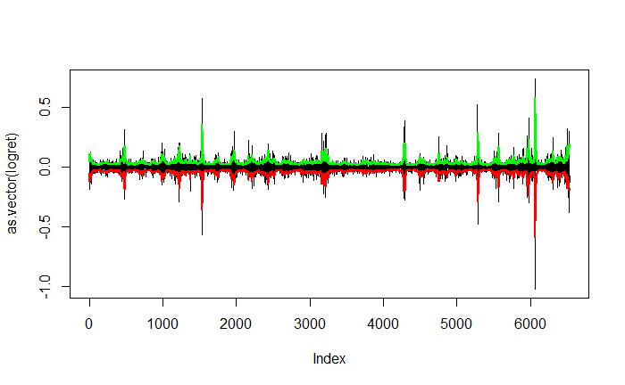

```r
lines(-as.vector(garch.1.1.results$sigma),col="red",lwd=2)
```

Normality of the residuals :

```r
epsilon <- as.vector(garch.1.1.results$residuals)/as.vector(garch.1.1.results$sigma)
hist(epsilon,main = "Histogram of epsilon",breaks=50,freq = F)
xfit <- seq(min(epsilon),max(epsilon),length=length(epsilon))
yfit <- dnorm(xfit,mean(epsilon),sd(epsilon))
lines(xfit,yfit,col="red",lwd=2)
```

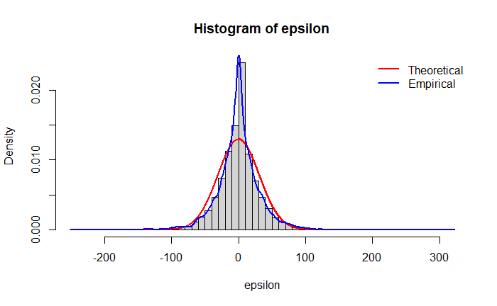

```r
lines(density(epsilon),col="blue",lwd=2)
legend("topright", legend = c("Theoretical","Empirical"),
       col = c("red", "blue"), lty = 1, lwd=2, bty = "n")
```

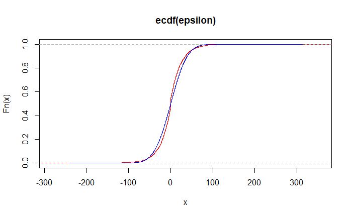

```r
plot(ecdf(epsilon),col="red")
lines(x=xfit,y=cumsum(yfit)/max(cumsum(yfit)),col="blue")
```

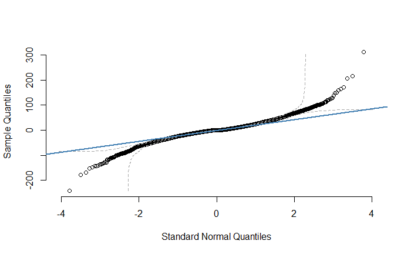

```r
qqnorm(epsilon, pch = 1, frame = FALSE)
qqline(epsilon, col = "steelblue", lwd = 2)
```

```r
jarque.test(epsilon)
```

```
    Jarque-Bera Normality Test

data:  epsilon
JB = 8009.2, p-value < 2.2e-16
alternative hypothesis: greater
```

The Jarque-Bera test shows that the residuals of the garch(1,1) model aren’t normal. GARCH(1,1)-t Model : using scaled t-distribution
$$r_t = \mu + \epsilon_t = \mu + \sigma_t \eta_t \\
\sigma_t^2 = \omega + \alpha \epsilon_t^2 + \beta \sigma_{t-1}^2 \\
\text{Where } \eta_t \sim t_v$$

```r
uspec <- ugarchspec( variance.model = list(model = "sGARCH",garchOrder = c(1,1)),
 mean.model = list(armaOrder = c(0,0), include.mean = TRUE),
 distribution.model = "std")
fit.garch.t <- ugarchfit(spec = uspec, data = logret)
```

```r
print(fit.garch.t@fit$coef)
```

```
           mu         omega        alpha1         beta1         shape
-5.081688e-05  7.453621e-05  1.871182e-01  7.889941e-01  4.791350e+00
```

```r
df.epsilon <- as.numeric(fit.garch.t@fit$coef[5])
df.epsilon
```

```
[1] 4.79135
```

```r
fit.garch.t.results <- data.frame(
  "logret" = logret,
  "sigma" = fit.garch.t@fit$sigma,
  "residuals" = fit.garch.t@fit$z)
```

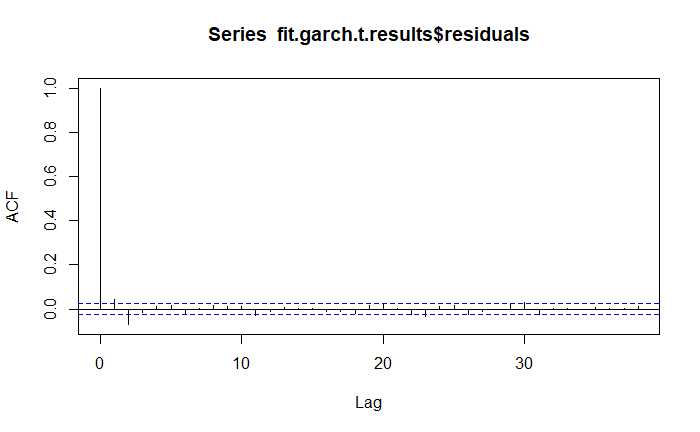

```r
acf(fit.garch.t.results$residuals)
```

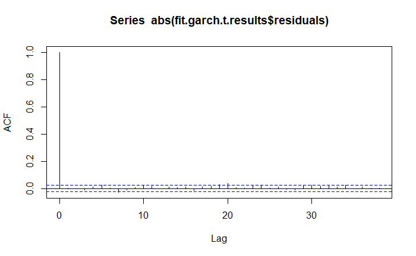

```r
acf(abs(fit.garch.t.results$residuals))
```

```r
plot(as.vector(logret),type="l")
lines(as.vector(fit.garch.t.results$sigma),col="green")
```

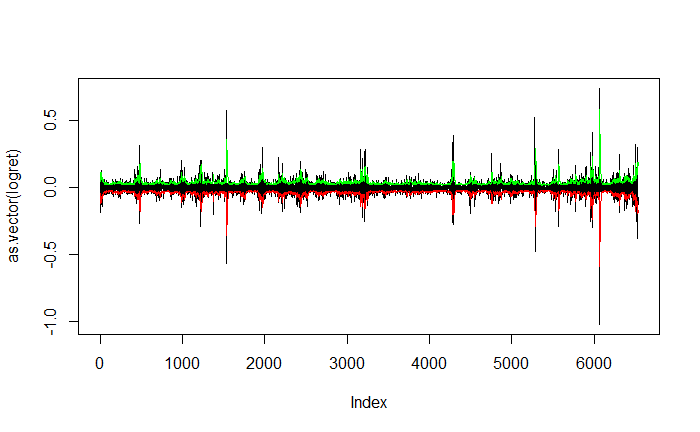

```r
lines(-as.vector(fit.garch.t.results$sigma),col="red")
```

```r
epsilon.t <- as.vector(fit.garch.t.results$residuals)
epsilon.t.fit <- fitdistr(as.vector(epsilon.t), "t")
```

```r
?fitdistr
```